# Bible Code Decoder

### Bibeltext importieren

```python
import pandas

dateipfad = "Genesis.csv"
tabelle = pandas.read_csv(dateipfad)

print(tabelle.head())
print("")
print(tabelle.info())
```

```
     Bibelvers                                               Text
0  Genesis 1:1                 בראשית ברא אלהים את השמים ואת הארץ
1  Genesis 1:2  והארץ היתה תהו ובהו וחשך על פני תהום ורוח אלהי...
2  Genesis 1:3                       ויאמר אלהים יהי אור ויהי אור
3  Genesis 1:4  וירא אלהים את האור כי טוב ויבדל אלהים בין האור...
4  Genesis 1:5  ויקרא אלהים לאור יום ולחשך קרא לילה ויהי ערב ו...

<class 'pandas.core.frame.DataFrame'>
RangeIndex: 1533 entries, 0 to 1532
Data columns (total 2 columns):
 #   Column     Non-Null Count  Dtype
---  ------     --------------  -----
 0   Bibelvers  1533 non-null   object
 1   Text       1533 non-null   object
dtypes: object(2)
memory usage: 24.1+ KB
None
```

```python
print(tabelle["Text"])
```

```
0                      בראשית ברא אלהים את השמים ואת הארץ
1       והארץ היתה תהו ובהו וחשך על פני תהום ורוח אלהי...
2                            ויאמר אלהים יהי אור ויהי אור
3       וירא אלהים את האור כי טוב ויבדל אלהים בין האור...
4       ויקרא אלהים לאור יום ולחשך קרא לילה ויהי ערב ו...
                              ...
1528    וישב יוסף במצרים הוא ובית אביו ויחי יוסף מאה ו...
1529    וירא יוסף לאפרים בני שלשים גם בני מכיר בן מנשה...
1530    ויאמר יוסף אל אחיו אנכי מת ואלהים פקד יפקד אתכ...
1531    וישבע יוסף את בני ישראל לאמר פקד יפקד אלהים את...
1532    וימת יוסף בן מאה ועשר שנים ויחנטו אתו ויישם בא...
Name: Text, Length: 1533, dtype: object
```

```python
print(tabelle.at[123, "Bibelvers"])
print(tabelle.at[123, "Text"])
```

```
Genesis 5:18
ויחי ירד שתים וששים שנה ומאת שנה ויולד את חנוך
```

```python
spaltenlänge = len(tabelle["Text"])
print(spaltenlänge)
```

```
1533
```

```python
bibelverse = []
for i in range(spaltenlänge):
    vers_name = tabelle.at[i, "Bibelvers"]
    bibelverse = bibelverse + [vers_name]

genesis_verse = []
for i in range(spaltenlänge):
    vers = tabelle.at[i, "Text"]
    genesis_verse = genesis_verse + [vers]

print(bibelverse[:20])
print(genesis_verse[:20])
```

```
['Genesis 1:1', 'Genesis 1:2', 'Genesis 1:3', 'Genesis 1:4', 'Genesis 1:5', 'Genesis 1:6', 'Genesis 1:7', 'Genesis 1:8', 'Genesis 1:9', 'Genesis 1:10', 'Genesis 1:11', 'Genesis 1:12', 'Genesis 1:13', 'Genesis 1:14', 'Genesis 1:15', 'Genesis 1:16', 'Genesis 1:17', 'Genesis 1:18', 'Genesis 1:19', 'Gen…
['בראשית ברא אלהים את השמים ואת הארץ', 'והארץ היתה תהו ובהו וחשך על פני תהום ורוח אלהים מרחפת על פני המים', 'ויאמר אלהים יהי אור ויהי אור', 'וירא אלהים את האור כי טוב ויבדל אלהים בין האור ובין החשך', 'ויקרא אלהים לאור יום ולחשך קרא לילה ויהי ערב ויהי בקר יום אחד', 'ויאמר אלהים יהי רקיע בתוך המים ויה…
```

Der Bibeltext ist jetzt in einer Liste. Jeder Vers ist ein Element in der Liste. Es gibt eine weitere Liste für die Namen der Bibelstellen.

```python
buchstabenliste = []
position_liste = []
for a in range(len(bibelverse)):
    for b in range(len(genesis_verse[a])):
        buchstabenliste.append(genesis_verse[a][b])
        position_liste.append(bibelverse[a])

print(buchstabenliste[:100])
print(position_liste[:100])
```

```
['ב', 'ר', 'א', 'ש', 'י', 'ת', ' ', 'ב', 'ר', 'א', ' ', 'א', 'ל', 'ה', 'י', 'ם', ' ', 'א', 'ת', ' ', 'ה', 'ש', 'מ', 'י', 'ם', ' ', 'ו', 'א', 'ת', ' ', 'ה', 'א', 'ר', 'ץ', 'ו', 'ה', 'א', 'ר', 'ץ', ' ', 'ה', 'י', 'ת', 'ה', ' ', 'ת', 'ה', 'ו', ' ', 'ו', 'ב', 'ה', 'ו', ' ', 'ו', 'ח', 'ש', 'ך', ' ', 'ע',…
['Genesis 1:1', 'Genesis 1:1', 'Genesis 1:1', 'Genesis 1:1', 'Genesis 1:1', 'Genesis 1:1', 'Genesis 1:1', 'Genesis 1:1', 'Genesis 1:1', 'Genesis 1:1', 'Genesis 1:1', 'Genesis 1:1', 'Genesis 1:1', 'Genesis 1:1', 'Genesis 1:1', 'Genesis 1:1', 'Genesis 1:1', 'Genesis 1:1', 'Genesis 1:1', 'Genesis 1:1',…
```

Jetzt gibt es eine Liste mit den einzelnen Buchstaben, die den Suchalgorithmus vereinfacht. Die Leerzeichen kann man aus der Liste entfernen und die Positionen auch aktualisieren:

```python
buchstabenliste = []
position_liste = []
for a in range(len(bibelverse)):
    for b in range(len(genesis_verse[a])):
        if genesis_verse[a][b] != " ":
            buchstabenliste.append(genesis_verse[a][b])
            position_liste.append(bibelverse[a])

print(buchstabenliste[:100])
print(position_liste[:100])
```

```
['ב', 'ר', 'א', 'ש', 'י', 'ת', 'ב', 'ר', 'א', 'א', 'ל', 'ה', 'י', 'ם', 'א', 'ת', 'ה', 'ש', 'מ', 'י', 'ם', 'ו', 'א', 'ת', 'ה', 'א', 'ר', 'ץ', 'ו', 'ה', 'א', 'ר', 'ץ', 'ה', 'י', 'ת', 'ה', 'ת', 'ה', 'ו', 'ו', 'ב', 'ה', 'ו', 'ו', 'ח', 'ש', 'ך', 'ע', 'ל', 'פ', 'נ', 'י', 'ת', 'ה', 'ו', 'ם', 'ו', 'ר', 'ו',…
['Genesis 1:1', 'Genesis 1:1', 'Genesis 1:1', 'Genesis 1:1', 'Genesis 1:1', 'Genesis 1:1', 'Genesis 1:1', 'Genesis 1:1', 'Genesis 1:1', 'Genesis 1:1', 'Genesis 1:1', 'Genesis 1:1', 'Genesis 1:1', 'Genesis 1:1', 'Genesis 1:1', 'Genesis 1:1', 'Genesis 1:1', 'Genesis 1:1', 'Genesis 1:1', 'Genesis 1:1',…
```

### Equidistant Letter Sequences suchen

Diese Version, die die Liste mit den Sätzen verwendet, würde einen zu komplexen Algorithmus benötigen:

```python
suchwort = "עשה"
sequences = []
verse = []
word_length = len(suchwort)

for j in range(len(genesis_verse)):
    sentence = genesis_verse[j]
    for i in range(len(sentence) - word_length + 1):
        if sentence[i:i + word_length] == suchwort:
            sequence = sentence[i:i + word_length]
            sequences.append(sequence)
            verse.append(bibelverse[j])

print(sequences)
print(verse)
```

```
['עשה', 'עשה', 'עשה', 'עשה', 'עשה', 'עשה', 'עשה', 'עשה', 'עשה', 'עשה', 'עשה', 'עשה', 'עשה', 'עשה', 'עשה', 'עשה', 'עשה', 'עשה', 'עשה', 'עשה', 'עשה', 'עשה', 'עשה', 'עשה', 'עשה', 'עשה', 'עשה', 'עשה', 'עשה', 'עשה', 'עשה', 'עשה', 'עשה', 'עשה', 'עשה', 'עשה', 'עשה', 'עשה', 'עשה', 'עשה', 'עשה', 'עשה', 'עשה'…
['Genesis 1:11', 'Genesis 1:12', 'Genesis 1:26', 'Genesis 1:31', 'Genesis 2:2', 'Genesis 2:2', 'Genesis 2:18', 'Genesis 3:1', 'Genesis 5:1', 'Genesis 6:6', 'Genesis 6:14', 'Genesis 6:14', 'Genesis 6:15', 'Genesis 6:16', 'Genesis 6:16', 'Genesis 6:22', 'Genesis 8:6', 'Genesis 9:6', 'Genesis 9:24', 'G…
```

Mit der Buchstabenliste kann man viel einfacher nach den Letter Sequences suchen:

```python
suchwort = "האור"
word_length = len(suchwort)

skip = 3
suchbereich = len(buchstabenliste) #buchstaben

sequences = []
verse = []


for a in range(suchbereich):
    current_word = ""
    for b in range(word_length):
        bereinigte_position = (a + skip * b) % suchbereich #Der Index darf nicht zu groß werden. Wenn ein Wort am Ende des Textes noch nicht fertig ist, sucht man am Anfang danach weiter
        current_letter = buchstabenliste[bereinigte_position]
        current_word = current_word + current_letter #Das Wort wird Buchstabe für Buchstabe zusammengesetzt
    if current_word == suchwort: #Wenn das konstruierte Wort das Suchwort ist, wird es zur Sequences Liste hinzugefügt
        sequences.append(current_word)
        verse.append(position_liste[a]) #Es wird der Vers des ersten Buchstabens genannt

print(sequences)
print(verse)
```

```
['האור', 'האור', 'האור', 'האור', 'האור', 'האור']
['Genesis 3:15', 'Genesis 22:14', 'Genesis 26:26', 'Genesis 33:16', 'Genesis 39:23', 'Genesis 46:7']
```

Jetzt kann man schon einzelne Letter Sequences im ganzen Text finden. Nun fehlt noch, verschiedene Skips zu versuchen. Dann wird der vollständige Text nach Sequences zu einem Wort abgefragt.

```python
suchwort = "מנשה"
word_length = len(suchwort)

max_skip = 50 #eigentlich int(len(buchstabenliste)/2), aber zu rechenaufwändig
suchbereich = len(buchstabenliste) #buchstaben

sequences = []
verwendete_skips = []
verse_vom_ersten_buchstaben = []


for start in range(suchbereich):
    for skip in range(max_skip):
        current_word = ""
        for b in range(word_length):
            bereinigte_position = (start + skip * b) % suchbereich #Der Index darf nicht zu groß werden. Wenn ein Wort am Ende des Textes noch nicht fertig ist, sucht man am Anfang danach weiter
            current_letter = buchstabenliste[bereinigte_position]
            current_word = current_word + current_letter #Das Wort wird Buchstabe für Buchstabe zusammengesetzt
        if current_word == suchwort: #Wenn das konstruierte Wort das Suchwort ist, wird es zur Sequences Liste hinzugefügt
            sequences.append(current_word)
            verwendete_skips.append(skip)
            verse_vom_ersten_buchstaben.append(position_liste[start]) #Es wird der Vers des ersten Buchstabens genannt

#print(sequences)
#print(verwendete_skips)
#print(verse_vom_ersten_buchstaben)

funde = pandas.DataFrame({"Wort":sequences, "Skip":verwendete_skips, "erster Buchstabe":verse_vom_ersten_buchstaben})
print(funde.head())
print("Anzahl der Funde: "+ str(len(funde["Wort"])))
```

```
   Wort  Skip erster Buchstabe
0  מנשה    17     Genesis 1:20
1  מנשה    37     Genesis 3:11
2  מנשה    41      Genesis 5:3
3  מנשה     5      Genesis 5:5
4  מנשה    21     Genesis 5:16
Anzahl der Funde: 42
```

```python
funde = pandas.DataFrame({"erster Buchstabe":verse_vom_ersten_buchstaben,"Skip":sequences, "Wort":verwendete_skips})#fehler: hebräische wörter werden in der spalte vertauscht
print(funde.head())
```

```
  erster Buchstabe  Skip  Wort
0     Genesis 1:20  מנשה    17
1     Genesis 3:11  מנשה    37
2      Genesis 5:3  מנשה    41
3      Genesis 5:5  מנשה     5
4     Genesis 5:16  מנשה    21
```

### Darstellen der Letter Sequences in einer Matrix

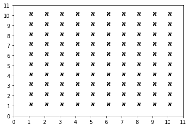

```python
import matplotlib.pyplot

for x in range(10):
    for y in range(10):
        matplotlib.pyplot.text(x+1,y+1, "א",fontsize=12, fontweight="bold")

matplotlib.pyplot.xticks(range(12),range(12))
matplotlib.pyplot.yticks(range(12),range(12))

matplotlib.pyplot.show()
```

Diese einfache Buchstabenmatrix kann man jetzt mit dem Bibeltext ausfüllen:

```python
def suche_els(suchwort, skips):
    suchbereich = len(buchstabenliste) #buchstaben

    els_liste = []
    for start in range(suchbereich):
        for skip in skips:
            current_word = ""
            for letter in range(len(suchwort)):
                bereinigte_position = (start + skip * letter) % suchbereich #Der Index darf nicht zu groß werden. Wenn ein Wort am Ende des Textes noch nicht fertig ist, sucht man am Anfang danach weiter
                current_letter = buchstabenliste[bereinigte_position]
                current_word = current_word + current_letter #Das Wort wird Buchstabe für Buchstabe zusammengesetzt
            if current_word == suchwort: #Wenn das konstruierte Wort das Suchwort ist, wird es zur Sequences Liste hinzugefügt
                els = [start, len(suchwort), skip]
                els_liste.append(els)
    return els_liste

def lese_els(els):
    #els = [start, length, skip]
    start = els[0]
    length = els[1]
    skip = els[2]
    vers = position_liste[start]

    wort = ""
    for letter in range(length):
        position = start+letter*skip
        wort += buchstabenliste[position]
    return [vers, wort]


suchwort = "מנשה"

els = suche_els(suchwort, range(-5, 5))
print(els)
for fund in els:
    print(lese_els(fund))

print("Anzahl der Funde: "+ str(len(els)))
```

```
[[5643, 4, -4], [5835, 4, -2], [5961, 4, -2], [6091, 4, -2], [6145, 4, -2], [11572, 4, -4], [30942, 4, -3], [62724, 4, 1], [71282, 4, 1], [74030, 4, 1], [74264, 4, 1], [74678, 4, 1], [74759, 4, 1], [74774, 4, 1], [75013, 4, 1], [75199, 4, 1], [75218, 4, 1], [77971, 4, 1]]
['Genesis 5:5', 'מנשה']
['Genesis 5:10', 'מנשה']
['Genesis 5:13', 'מנשה']
['Genesis 5:16', 'מנשה']
['Genesis 5:17', 'מנשה']
['Genesis 9:29', 'מנשה']
['Genesis 24:30', 'מנשה']
['Genesis 41:51', 'מנשה']
['Genesis 46:20', 'מנשה']
['Genesis 48:1', 'מנשה']
['Genesis 48:5', 'מנשה']
['Genesis 48:13', 'מנשה']
['Genesis 48:14', 'מנשה']
['Genesis 48:14', 'מנשה']
['Genesis 48:17', 'מנשה']
['Genesis 48:20', 'מנשה']
['Genesis 48:20', 'מנשה']
['Genesis 50:23', 'מנשה']
Anzahl der Funde: 18
```

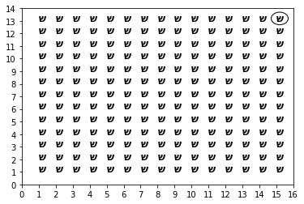

```python
import numpy

def plot_text(text, marked, rows, lines):
    start = 0
    for y in range(lines):
        for x in range(rows):
            matplotlib.pyplot.text(rows-x, lines-y , text[start+(rows*y)+x],fontsize=12, fontweight="bold")
            if marked[(rows*y)+x] == 1:
                matplotlib.pyplot.gca().add_artist(matplotlib.pyplot.Circle((rows-x+0.2, lines-y+0.2), radius=0.5, fill=False))

    matplotlib.pyplot.xticks(range(rows + 2),range(rows + 2))
    matplotlib.pyplot.yticks(range(lines + 2),range(lines + 2))

    matplotlib.pyplot.show()

example = ["ש"]*1000
marked = [0]*1000
marked[0] = 1
plot_text(example, marked, 15, 13)
```

```
[[5625, 4, 5], [5643, 4, -4], [5835, 4, -2], [5961, 4, -2], [6091, 4, -2], [6145, 4, -2], [11523, 4, 5], [11554, 4, 5], [11572, 4, -4], [14706, 4, 12], [29430, 4, 14], [30942, 4, -3], [52614, 4, 6], [62724, 4, 1], [64685, 4, 5], [71282, 4, 1], [74030, 4, 1], [74264, 4, 1], [74678, 4, 1], [74759, 4, …
['Genesis 5:5', 'מנשה']
['Genesis 5:5', 'מנשה']
['Genesis 5:10', 'מנשה']
['Genesis 5:13', 'מנשה']
['Genesis 5:16', 'מנשה']
['Genesis 5:17', 'מנשה']
['Genesis 9:28', 'מנשה']
['Genesis 9:29', 'מנשה']
['Genesis 9:29', 'מנשה']
['Genesis 12:11', 'מנשה']
['Genesis 24:2', 'מנשה']
['Genesis 24:30', 'מנשה']
['Genesis 36:7', 'מנשה']
['Genesis 41:51', 'מנשה']
['Genesis 42:33', 'מנשה']
['Genesis 46:20', 'מנשה']
['Genesis 48:1', 'מנשה']
['Genesis 48:5', 'מנשה']
['Genesis 48:13', 'מנשה']
['Genesis 48:14', 'מנשה']
['Genesis 48:14', 'מנשה']
['Genesis 48:17', 'מנשה']
['Genesis 48:20', 'מנשה']
['Genesis 48:20', 'מנשה']
['Genesis 50:23', 'מנשה']
Anzahl der Funde: 25
Fund 0:
```

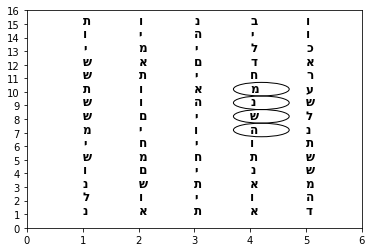

```
['Genesis 5:5', 'מנשה']
```

```python
suchwort = "מנשה"

els = suche_els(suchwort, range(-5, 15))
print(els)
for fund in els:
    print(lese_els(fund))

print("Anzahl der Funde: "+ str(len(els)))

def display_matrix(text, els, shift, top_space, right_space):
    max_rows = 20
    lines = 15
    #els = [start, length, skip]
    start = els[0]
    length = els[1]
    skip = els[2]

    miss_out = 0
    rows = (numpy.abs(skip)-shift)
    if rows > max_rows: #anzahl der spalten begrenzen
        rows = max_rows

    marked = [0]*len(text) #umkreisen der gefundenen buchstaben
    for letter in range(length):
        marked[rows*top_space+right_space+letter*skip] = 1

    focused_text = [] #die angezeigten buchstaben filtern
    for line in range(lines):
        focused_text = focused_text + text[start-right_space+(rows+miss_out)*(line-top_space):start-right_space+(rows+miss_out)*(line-top_space)+rows]

    if shift >= numpy.abs(skip):
        print("Achtung: Der Shift darf nicht größer/gleich dem Skip des ELS sein!!!")
    plot_text(focused_text, marked, rows, lines)
    print(lese_els(els))


auswahl = 0
print("Fund "+ str(auswahl) + ":")
display_matrix(buchstabenliste, els[auswahl], 0, 4, 6)
```

```
[]
Anzahl der Funde: 0
Fund 0:
[[7, 4, 50], [0, 5, 1]]
```

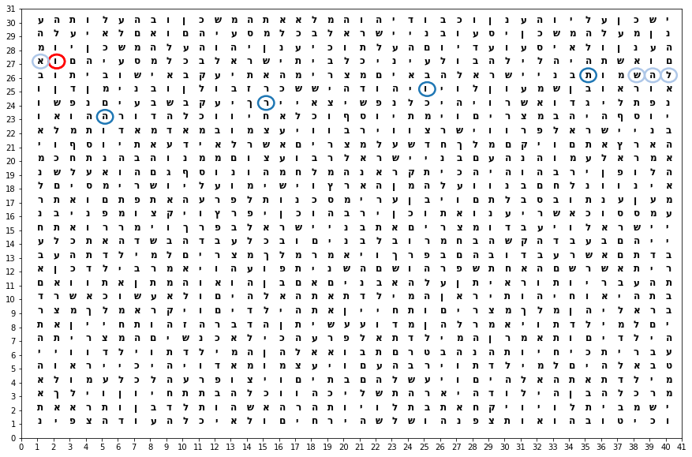

```
Anzeige von Buchstabe-158 bis 1082
['Exodus 1:1', 'תורה']
```

```python
import pandas
import numpy
import matplotlib.pyplot

hebraeisch_liste = ["א", "ב", "ג", "ד", "ה", "ו", "ז", "ח", "ט", "י", "ך", "כ", "ל", "ם", "מ", "ן", "נ", "ס", "ע", "ף", "פ", "ץ", "צ", "ק", "ר", "ש", "ת"]
mappung = {char: i for i, char in enumerate(hebraeisch_liste)}

def kodieren(text):
    """Verschlüsselt den gegebenen Text basierend auf der bereitgestellten Mappung."""
    return [mappung.get(char, char) for char in text]

def dekodieren(verschluesselt):
    """Entschlüsselt den verschlüsselten Text basierend auf der bereitgestellten Zeichenliste."""
    text = []
    for zahl in verschluesselt:
        if isinstance(zahl, int):
            text.append(hebraeisch_liste[zahl])
    return text

G = "Genesis.csv"
E = "Exodus.csv"
dateipfad = E
tabelle = pandas.read_csv(dateipfad)
spaltenlänge = len(tabelle["Text"])

bibelverse = []
for i in range(spaltenlänge):
    vers_name = tabelle.at[i, "Bibelvers"]
    bibelverse = bibelverse + [vers_name]

genesis_verse = []
for i in range(spaltenlänge):
    vers = tabelle.at[i, "Text"]
    genesis_verse = genesis_verse + [vers]

buchstabenliste = []
position_liste = []
for a in range(len(bibelverse)):
    for b in range(len(genesis_verse[a])):
        if genesis_verse[a][b] != " ":
            buchstabenliste.append(genesis_verse[a][b])
            position_liste.append(bibelverse[a])

def suche_els(suchwort, skips):
    suchbereich = len(buchstabenliste) #buchstaben

    els_liste = []
    for start in range(suchbereich):
        for skip in skips:
            current_word = ""
            for letter in range(len(suchwort)):
                bereinigte_position = (start + skip * letter) % suchbereich #Der Index darf nicht zu groß werden. Wenn ein Wort am Ende des Textes noch nicht fertig ist, sucht man am Anfang danach weiter
                current_letter = buchstabenliste[bereinigte_position]
                current_word = current_word + current_letter #Das Wort wird Buchstabe für Buchstabe zusammengesetzt
            if current_word == suchwort: #Wenn das konstruierte Wort das Suchwort ist, wird es zur Sequences Liste hinzugefügt
                els = [start, len(suchwort), skip]
                els_liste.append(els)
    return els_liste

def lese_els(els):
    #els = [start, length, skip]
    start = els[0]
    length = els[1]
    skip = els[2]
    vers = position_liste[start]

    wort = ""
    for letter in range(length):
        position = start+letter*skip
        wort += buchstabenliste[position]
    return [vers, wort]

def plot_text(focused_text, marked, rows, lines, position):
    matplotlib.pyplot.figure(figsize=(15,10))
    for y in range(lines):
        for x in range(rows):
            matplotlib.pyplot.text(rows-x, lines-y , focused_text[rows*y+x],fontsize=12, fontweight="bold")
            c = 1
            for marker in marked:
                if marker[position+(rows*y)+x] == 1:
                    matplotlib.pyplot.gca().add_artist(matplotlib.pyplot.Circle((rows-x+0.2, lines-y+0.2), radius=0.5, linewidth= 2.5, fill=False, color = matplotlib.cm.get_cmap("tab20")(1/20*c-0.01)))
                if marker[position+(rows*y)+x] == 2:
                    matplotlib.pyplot.gca().add_artist(matplotlib.pyplot.Circle((rows-x+0.2, lines-y+0.2), radius=0.5, linewidth= 2.5, fill=False, color = "r"))
                c += 1

    matplotlib.pyplot.xticks(range(rows + 2),range(rows + 2))
    matplotlib.pyplot.yticks(range(lines + 2),range(lines + 2))
    matplotlib.pyplot.show()

def display_matrix(text, anchor_els, andere_els, shift, top_space, right_space):
    kodierter_text=kodieren("".join(text))
    max_rows = 40
    lines = 30
    miss_out = 0
    rows = (numpy.abs(anchor_els[2])-shift)
    if rows > max_rows: #anzahl der spalten begrenzen
        rows = max_rows
    elss = [anchor_els] + andere_els
    markers = []
    print(elss)
    for els in elss:
        #els = [start, length, skip]
        start = els[0]
        length = els[1]
        skip = els[2]

        marked = [0]*len(text) #umkreisen der gefundenen buchstaben
        for letter in range(length):
            marked[start+letter*skip] = 1
        marked[0] = 2
        markers = markers + [marked]

    focused_text = [] #die angezeigten buchstaben filtern
    start_index = anchor_els[0] - (right_space + rows*top_space)
    end_index = start_index + (rows * (lines + 1))
    focused_text = kodierter_text[start_index:end_index] if start_index >= 0 else kodierter_text[start_index:]+kodierter_text[:end_index]

    if shift >= numpy.abs(anchor_els[2]):
        print("Achtung: Der Shift darf nicht größer/gleich dem Skip des ELS sein!!!")

    plot_text(dekodieren(focused_text), markers, rows, lines, start_index)
    print("Anzeige von Buchstabe" + str(start_index) + " bis " + str(end_index))
    print(lese_els(anchor_els))


suchwort = "תורה"
els = suche_els(suchwort, range(0, 1))
print(els)
for fund in els:
    print(lese_els(fund))

print("Anzahl der Funde: "+ str(len(els)))


auswahl = 0
print("Fund "+ str(auswahl) + ":")
display_matrix(buchstabenliste, [7,4,50], [[0,5,1]], 0, 4, 5) #els[auswahl]  els[auswahl+1:]
```

### Hier wurden die wichtigsten Funktionen ausgelagert:

```
[[5, 4, 50], [37, 4, 57], [113, 4, -58], [659, 4, 16], [788, 4, -27], [1191, 4, -13], [1518, 4, -2], [2468, 4, 4], [2705, 4, 21], [2901, 4, -9], [3334, 4, 55], [3746, 4, -9], [4009, 4, 10], [4222, 4, 53], [4235, 4, -1], [4244, 4, -20], [4277, 4, -15], [4952, 4, -1], [5339, 4, -42], [5579, 4, -52], […
Anzahl der Funde: 279
Fund 0:
```

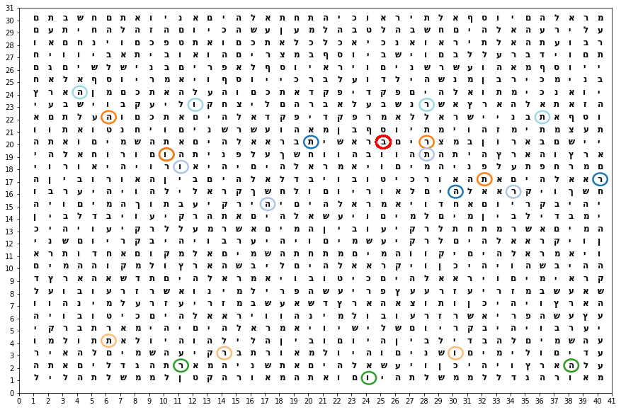

```
Anzeige von Buchstabe -415 bis 825
['Genesis 1:1', 'תורה']
```

```python
import biblecode_funktionen

G = "Genesis.csv"
E = "Exodus.csv"

buchstabenliste, position_liste = biblecode_funktionen.text_besorgen(G)

suchwort = "תורה"
els = biblecode_funktionen.suche_els(buchstabenliste, suchwort, range(-60, 60))
print(els)
#for fund in els:
#    print(biblecode_funktionen.lese_els(fund, buchstabenliste, position_liste))

print("Anzahl der Funde: "+ str(len(els)))


auswahl = 0
print("Fund "+ str(auswahl) + ":")
biblecode_funktionen.display_matrix(buchstabenliste, position_liste, els[auswahl], els[auswahl+1:], 0, 10, 20)
```

### Distance between ELS's

Man kann zwei Entfernungen messen. Jenachdem, wo der Zylinder aufgeschnitten wird. Die kleinere Entfernung wird weiterverwendet:

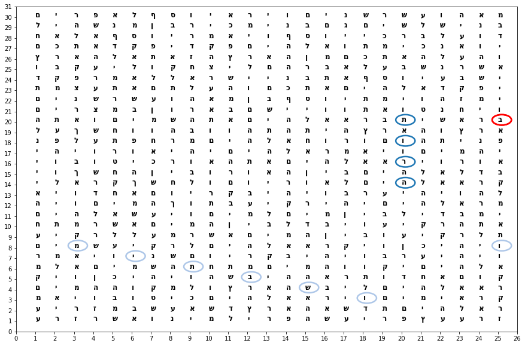

```
Anzeige von Buchstabe -250 bis 525
['Genesis 1:1', 'תורה']
```

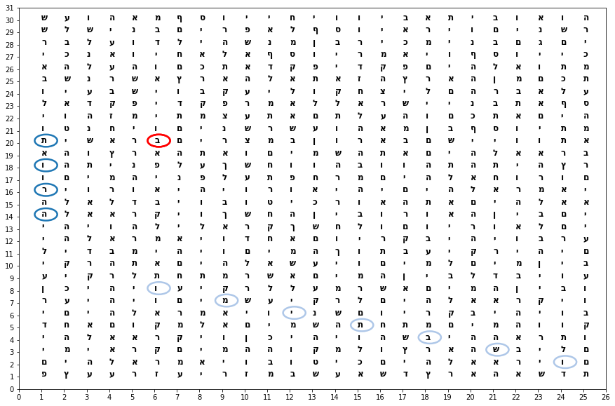

```
Anzeige von Buchstabe -269 bis 506
['Genesis 1:1', 'תורה']
```

```python
import biblecode_funktionen

G = "Genesis.csv"
E = "Exodus.csv"

buchstabenliste, position_liste = biblecode_funktionen.text_besorgen(G)

biblecode_funktionen.display_matrix(buchstabenliste, position_liste, [5,4,50], [[300,7,22]], 25, 10, 5)

biblecode_funktionen.display_matrix(buchstabenliste, position_liste, [5,4,50], [[300,7,22]], 25, 10, 24)
```

```python
import numpy
import matplotlib.pyplot

def letter_position(place, columns):
    x = place%columns
    y = divmod(place, columns)[0]
    return [x, y]

def els_position(els, columns):
    position = []
    start = els[0]
    length = els[1]
    skip = els[2]
    for letter in range(length):
        place = start + letter*skip
        position.append(letter_position(place, columns))
    return position

def letter_distance(pos_letter1, pos_letter2, columns):
    d_x1 = numpy.abs(pos_letter1[0]-pos_letter2[0])
    d_x2 = columns - d_x1
    d_y = numpy.abs(pos_letter1[1]-pos_letter2[1])
    a = numpy.sqrt(numpy.square(d_x1)+numpy.square(d_y))
    b = numpy.sqrt(numpy.square(d_x2)+numpy.square(d_y))
    d = min(a, b)
    return d

def els_distance(els1, els2, columns):
    #poisionen der buchstaben berechnen
    pos_els1 = els_position(els1, columns)
    pos_els2 = els_position(els2, columns)
    #entfernungen berechnen
    #minimale distanz von zwei buchstaben der verschiedenen wörter
    letter_distances = numpy.empty((len(pos_els1),len(pos_els2)))
    for letter1 in range(len(pos_els1)):
        for letter2 in range(len(pos_els2)):
            letter_distances[letter1, letter2] = letter_distance(pos_els1[letter1], pos_els2[letter2], columns) #die abstände zwischen allen buchstaben werden in einem array dargestellt
    l = numpy.min(letter_distances) #der kleinste abstand wird ausgewählt
    #distancen der einzelnen buchstaben im wort
    f = letter_distance(pos_els1[0], pos_els1[1], columns)
    f_strich = letter_distance(pos_els2[0], pos_els2[1], columns)
    return numpy.square(f) + numpy.square(f_strich) + numpy.square(l)

def maximum_compactness(els1, els2):
    skip1 = els1[2]
    skip2 = els2[2]
    compactness = 0

    for i in range(1, 10):
        h_i = numpy.round(numpy.abs(skip1)/i)
        if h_i < 1:
            h_i = 1
        mü_hi = 1/els_distance(els1, els2, h_i)
        compactness += mü_hi

    for i in range(1, 10):
        h_strich_i = numpy.round(numpy.abs(skip2)/i)
        if h_strich_i < 1:
            h_strich_i = 1
        mü_hstrichi = 1/els_distance(els1, els2, h_strich_i)
        compactness += mü_hstrichi

    return compactness

#els_distance([5,4,50], [300,7,22], 25)
#1/els_distance([5,4,50], [8,4,1], 50)
maximum_compactness([5,4,50], [5,4,50])
```

```
1.508529411764706
```

```python
import biblecode_funktionen

biblecode_funktionen.maximum_compactness([5,4,50], [5,4,50])
```

```
1.508529411764706
```

```
[[1191, 4, -13], [2901, 4, -9], [3746, 4, -9], [4244, 4, -20], [4277, 4, -15], [7119, 4, -17], [8243, 4, -8], [9970, 4, -10], [10221, 4, -14], [11361, 4, -4], [11966, 4, -13], [12180, 4, -19], [13713, 4, -11], [14015, 4, -7], [15379, 4, -7], [15916, 4, -18], [18377, 4, -5], [20910, 4, -14], [23626, …
Anzahl der Funde: 73
[[5643, 4, -4], [11466, 4, -7], [11572, 4, -4], [15212, 4, -12], [29702, 4, -10], [30942, 4, -3], [33490, 4, -20], [956, 4, 17], [5625, 4, 5], [11523, 4, 5], [11554, 4, 5], [14706, 4, 12], [29430, 4, 14], [31439, 4, 17], [33497, 4, 18], [35608, 4, 17], [39214, 4, 15], [52614, 4, 6], [64685, 4, 5], […
Anzahl der Funde: 20
```

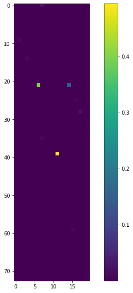

```python
import biblecode_funktionen
import matplotlib.pyplot
import numpy

G = "Genesis.csv"
E = "Exodus.csv"

buchstabenliste, position_liste = biblecode_funktionen.text_besorgen(G)

suchwort1 = "תורה"
els_neg1 = biblecode_funktionen.suche_els(buchstabenliste, suchwort1, range(-20, -2))
els_pos1 = biblecode_funktionen.suche_els(buchstabenliste, suchwort1, range(2, 20))
els1 = els_neg1 + els_pos1
print(els1)
print("Anzahl der Funde: "+ str(len(els1)))

suchwort2 = "מנשה"
els_neg2 = biblecode_funktionen.suche_els(buchstabenliste, suchwort2, range(-20, -2))
els_pos2 = biblecode_funktionen.suche_els(buchstabenliste, suchwort2, range(2, 20))
els2 = els_neg2 + els_pos2
print(els2)
print("Anzahl der Funde: "+ str(len(els2)))

def berechne_nähe(els1, els2):
    compactnesses = numpy.empty((len(els1),len(els2)))
    for word1 in range(len(els1)):
        for word2 in range(len(els2)):
            compactnesses[word1, word2] = biblecode_funktionen.maximum_compactness(els1[word1], els2[word2])
    return compactnesses

matplotlib.pyplot.figure(figsize=(10,10))
matplotlib.pyplot.imshow(berechne_nähe(els1,els2))
matplotlib.pyplot.colorbar()
```

```python
def kompakteste_funde(els1, els2, n):
    compactnesses = berechne_nähe(els1, els2)
    max_pairs = []
    for max in range(n):
        maximum = numpy.argmax(compactnesses)
        max_position = [divmod(maximum, len(els2))[0], maximum%len(els2)]
        max_pairs.append([els1[max_position[0]], els2[max_position[1]]])
        compactnesses[max_position[0],max_position[1]] = 0
    return max_pairs

signifikante_funde = kompakteste_funde(els1, els2, 10)
print(signifikante_funde)
```

```
[[[14725, 4, 16], [14706, 4, 12]], [[33452, 4, -14], [33490, 4, -20]], [[33452, 4, -14], [33497, 4, 18]], [[52495, 4, -18], [52614, 4, 6]], [[1191, 4, -13], [956, 4, 17]], [[11361, 4, -4], [11466, 4, -7]], [[15379, 4, -7], [15212, 4, -12]], [[659, 4, 16], [956, 4, 17]], [[35910, 4, 15], [35608, 4, 1…
```

```
Signifikanteste Überschneidung:
```

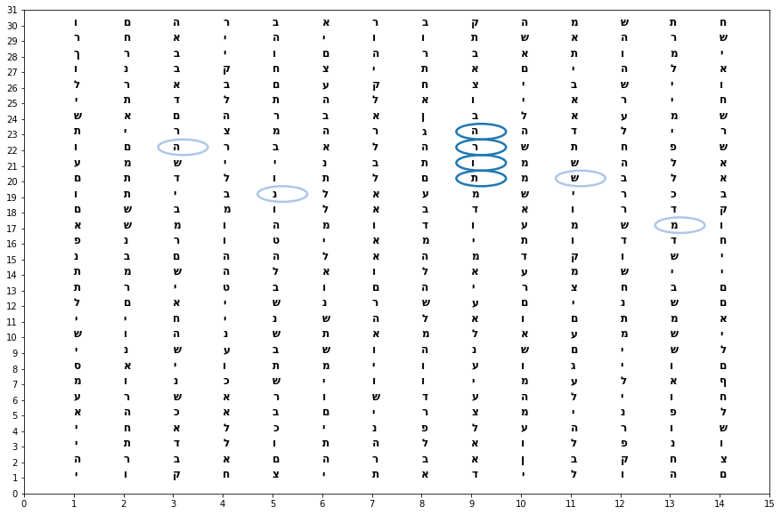

```
Anzeige von Buchstabe 33307 bis 33741
['Genesis 25:13', 'תורה']
```

```python
import biblecode_funktionen

G = "Genesis.csv"
E = "Exodus.csv"

buchstabenliste, position_liste = biblecode_funktionen.text_besorgen(G)

auswahl = 1 #0...9
print("Signifikanteste Überschneidung:")
biblecode_funktionen.display_matrix(buchstabenliste, position_liste, signifikante_funde[auswahl][0], [signifikante_funde[auswahl][1]], 0, 10, 5)
```

```
[[207, 4, -18], [1193, 4, -14], [2026, 4, -13], [3312, 4, -19], [5219, 4, -15], [5353, 4, -20], [10559, 4, -11], [12224, 4, -17], [14962, 4, -3], [16685, 4, -16], [23726, 4, -19], [30100, 4, -15], [33269, 4, -7], [33299, 4, -20], [35787, 4, -5], [41640, 4, -16], [41879, 4, -20], [43756, 4, -13], [45…
72 Funde für תורה
[[7646, 4, -17], [12248, 4, -18], [15669, 4, -15], [37417, 4, -14], [8542, 4, 15], [25175, 4, 17], [27638, 4, 11], [44630, 4, 16], [49614, 4, 11], [63031, 4, 13]]
10 Funde für מנשה
Nähe der einzelnen ELS's:
```

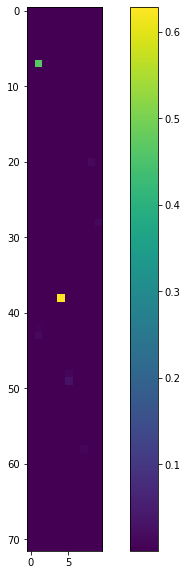

```
Signifikante Funde:
[[[8533, 4, 14], [8542, 4, 15]], [[12224, 4, -17], [12248, 4, -18]], [[24974, 4, 19], [25175, 4, 17]], [[12416, 4, 7], [12248, 4, -18]], [[62881, 4, -9], [63031, 4, 13]], [[49409, 4, -19], [49614, 4, 11]], [[44926, 4, 15], [44630, 4, 16]], [[24820, 4, 19], [25175, 4, 17]], [[11892, 4, 4], [12248, 4,…
Signifikanteste Überschneidung:
```

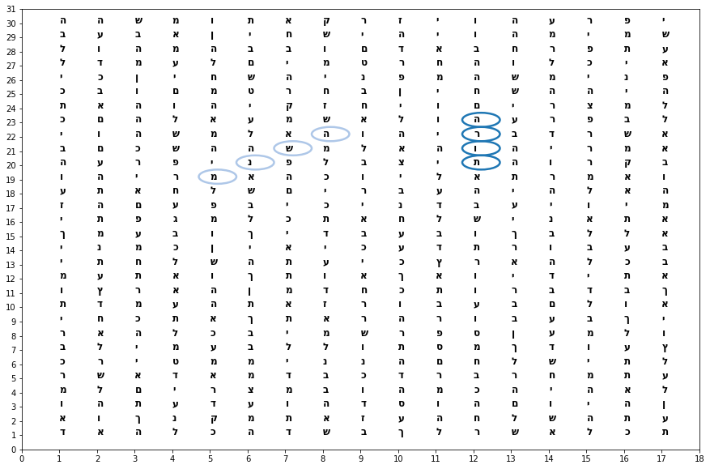

```
Anzeige von Buchstabe 12049 bis 12576
['Exodus 9:13', 'תורה']
```

```python
import biblecode_funktionen
import matplotlib.pyplot
import numpy

G = "Genesis.csv"
E = "Exodus.csv"

buchstabenliste, position_liste = biblecode_funktionen.text_besorgen(E)

suchwort1 = "תורה"
suchwort2 = "מנשה"

els_neg1 = biblecode_funktionen.suche_els(buchstabenliste, suchwort1, range(-20, -2))
els_pos1 = biblecode_funktionen.suche_els(buchstabenliste, suchwort1, range(2, 20))
els1 = els_neg1 + els_pos1
print(els1)
print(str(len(els1)) + " Funde für " + suchwort1)
els_neg2 = biblecode_funktionen.suche_els(buchstabenliste, suchwort2, range(-20, -2))
els_pos2 = biblecode_funktionen.suche_els(buchstabenliste, suchwort2, range(2, 20))
els2 = els_neg2 + els_pos2
print(els2)
print(str(len(els2)) + " Funde für " + suchwort2)

print("Nähe der einzelnen ELS's:")
matplotlib.pyplot.figure(figsize=(10,10))
matplotlib.pyplot.imshow(biblecode_funktionen.berechne_nähe(els1,els2))
matplotlib.pyplot.colorbar()
matplotlib.pyplot.show()

signifikante_funde = biblecode_funktionen.kompakteste_funde(els1, els2, 10)
print("Signifikante Funde:")
print(signifikante_funde)

auswahl = 1 #0...9
print("Signifikanteste Überschneidung:")
biblecode_funktionen.display_matrix(buchstabenliste, position_liste, signifikante_funde[auswahl][0], [signifikante_funde[auswahl][1]], 0, 10, 5)
```

### Zufälliger Text:

```python
import random

def random_text(length):
    kodiert = []
    for letter in range(length):
        zahl = random.randint(0, 26)
        kodiert.append(zahl)
    text = biblecode_funktionen.dekodieren(kodiert)
    return text

print(random_text(200))
```

```
['ק', 'ק', 'מ', 'ד', 'ד', 'ל', 'ץ', 'ק', 'ו', 'ץ', 'נ', 'ך', 'ט', 'י', 'ר', 'ק', 'ג', 'י', 'י', 'ב', 'ס', 'ב', 'ב', 'ג', 'ץ', 'ז', 'י', 'כ', 'ן', 'ן', 'ץ', 'ד', 'ל', 'ד', 'ס', 'ש', 'ד', 'ר', 'ט', 'ם', 'ג', 'ו', 'ד', 'ק', 'ס', 'נ', 'ח', 'ל', 'ד', 'ן', 'ס', 'ץ', 'ז', 'ס', 'ה', 'ב', 'ש', 'ם', 'ד', 'נ',…
```

```
[[1191, 4, -13], [2901, 4, -9], [3746, 4, -9], [4244, 4, -20], [4277, 4, -15], [7119, 4, -17], [8243, 4, -8], [9970, 4, -10], [10221, 4, -14], [11361, 4, -4], [11966, 4, -13], [12180, 4, -19], [13713, 4, -11], [14015, 4, -7], [15379, 4, -7], [15916, 4, -18], [18377, 4, -5], [20910, 4, -14], [23626, …
73 Funde für תורה
[[5643, 4, -4], [11466, 4, -7], [11572, 4, -4], [15212, 4, -12], [29702, 4, -10], [30942, 4, -3], [33490, 4, -20], [956, 4, 17], [5625, 4, 5], [11523, 4, 5], [11554, 4, 5], [14706, 4, 12], [29430, 4, 14], [31439, 4, 17], [33497, 4, 18], [35608, 4, 17], [39214, 4, 15], [52614, 4, 6], [64685, 4, 5], […
20 Funde für מנשה
Nähe der einzelnen ELS's:
```

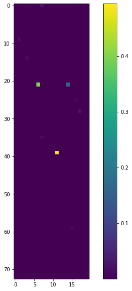

```
Signifikante Funde:
[[[14725, 4, 16], [14706, 4, 12], 0.4939279420047315], [[33452, 4, -14], [33490, 4, -20], 0.4001781738336359], [[33452, 4, -14], [33497, 4, 18], 0.15282999544563358], [[52495, 4, -18], [52614, 4, 6], 0.026531389831422968], [[1191, 4, -13], [956, 4, 17], 0.0253744842872898], [[11361, 4, -4], [11466, …
Signifikanteste Überschneidung:
```

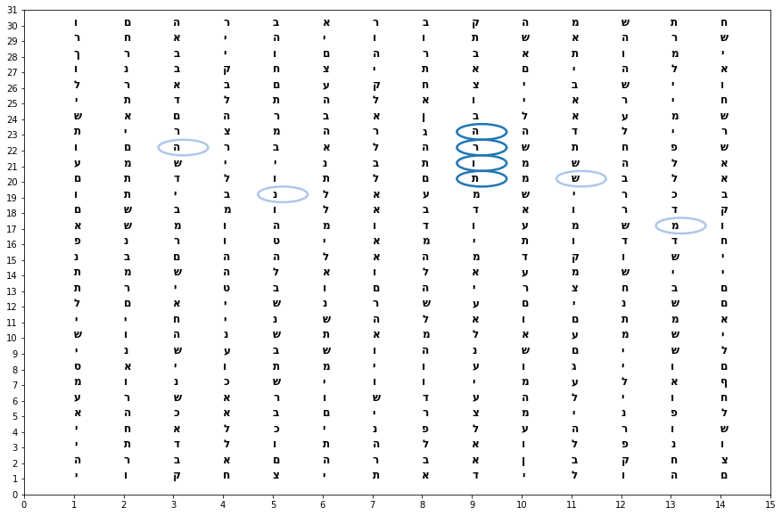

```
Anzeige von Buchstabe 33307 bis 33741
['Genesis 25:13', 'תורה']
```

```python
import biblecode_funktionen
import matplotlib.pyplot
import numpy

G, G_VersN = biblecode_funktionen.bibeltext_besorgen("Genesis.csv")
E, E_VersN = biblecode_funktionen.bibeltext_besorgen("Exodus.csv")
R, R_Pos = biblecode_funktionen.random_text(len(G))


buchstabenliste = G
position_liste = G_VersN

suchwort1 = "תורה"
suchwort2 = "מנשה"

els_neg1 = biblecode_funktionen.suche_els(buchstabenliste, suchwort1, range(-20, -2))
els_pos1 = biblecode_funktionen.suche_els(buchstabenliste, suchwort1, range(2, 20))
els1 = els_neg1 + els_pos1
print(els1)
print(str(len(els1)) + " Funde für " + suchwort1)
els_neg2 = biblecode_funktionen.suche_els(buchstabenliste, suchwort2, range(-20, -2))
els_pos2 = biblecode_funktionen.suche_els(buchstabenliste, suchwort2, range(2, 20))
els2 = els_neg2 + els_pos2
print(els2)
print(str(len(els2)) + " Funde für " + suchwort2)

print("Nähe der einzelnen ELS's:")
matplotlib.pyplot.figure(figsize=(10,10))
matplotlib.pyplot.imshow(biblecode_funktionen.berechne_nähe(els1,els2))
matplotlib.pyplot.colorbar()
matplotlib.pyplot.show()

signifikante_funde = biblecode_funktionen.kompakteste_funde(els1, els2, 10)
print("Signifikante Funde:")
print(signifikante_funde)

auswahl = 1 #0...9
print("Signifikanteste Überschneidung:")
biblecode_funktionen.display_matrix(buchstabenliste, position_liste, signifikante_funde[auswahl][0], [signifikante_funde[auswahl][1]], 0, 10, 5)
```

### Andere Hebräische Texte besorgen:

```python
import re

def bereinige_text(text):
    # Hebräische Buchstaben-Unicode-Bereiche
    hebrew_unicode_ranges = [
        #(u'\u0591', u'\u05F4'),  # Hebräische Punkte und Akzente
        (u'\u05D0', u'\u05EA')   # Hebräische Buchstaben
    ]

    hebrew_pattern = '|'.join([f'[{start}-{end}]' for start, end in hebrew_unicode_ranges])

    # Nur hebräische Zeichen extrahieren
    return ''.join(re.findall(hebrew_pattern, text))

# Datei einlesen und bereinigen
with open('Talmund_Shabbat_Original.txt', 'r', encoding='utf-8') as file:
    inhalt = file.read()

bereinigter_inhalt = bereinige_text(inhalt)

# Ergebnis in eine neue Datei schreiben oder weiterverarbeiten
with open('Talmund_Shabbat_Bereinigt.txt', 'w', encoding='utf-8') as file:
    file.write(bereinigter_inhalt)

print("Talmund_Shabbat Text wurde bereinigt")
```

```
Talmund_Shabbat Text wurde bereinigt
```

```python
with open('Ben_Sira_Original.txt', 'r', encoding='utf-8') as file:
    inhalt = file.read()

bereinigter_inhalt = bereinige_text(inhalt)

# Ergebnis in eine neue Datei schreiben oder weiterverarbeiten
with open('Ben_Sira_Bereinigt.txt', 'w', encoding='utf-8') as file:
    file.write(bereinigter_inhalt)

print("Ben Sira Text wurde bereinigt")
```

```
Ben Sira Text wurde bereinigt
```

```python
def lese_txt(dateiname):
    buchstaben_liste = []
    positionen = []

    # Bereinigte Datei lesen
    with open(dateiname, 'r', encoding='utf-8') as file:
        bereinigter_inhalt = file.read()

    # Buchstaben in die Liste hinzufügen
    for letter in range(len(bereinigter_inhalt)):
        buchstaben_liste.append(bereinigter_inhalt[letter])
        positionen.append(letter)

    # Ausgabe der Buchstabenliste (optional)
    return buchstaben_liste, positionen

text, positionen = lese_txt("Ben_Sira_Bereinigt.txt")
print(text[:100])
print(positionen[:100])
```

```
['ב', 'ן', 'ס', 'י', 'ר', 'א', 'ב', 'ן', 'ס', 'י', 'ר', 'א', 'כ', 'ל', 'ח', 'כ', 'מ', 'ה', 'מ', 'י', 'ה', 'ו', 'ה', 'ו', 'ע', 'מ', 'ו', 'ה', 'י', 'א', 'ל', 'ע', 'ו', 'ל', 'מ', 'י', 'ם', 'ח', 'ו', 'ל', 'י', 'מ', 'י', 'ם', 'ו', 'נ', 'ט', 'פ', 'י', 'מ', 'ט', 'ר', 'ו', 'י', 'מ', 'ו', 'ת', 'ע', 'ו', 'ל',…
[0, 1, 2, 3, 4, 5, 6, 7, 8, 9, 10, 11, 12, 13, 14, 15, 16, 17, 18, 19, 20, 21, 22, 23, 24, 25, 26, 27, 28, 29, 30, 31, 32, 33, 34, 35, 36, 37, 38, 39, 40, 41, 42, 43, 44, 45, 46, 47, 48, 49, 50, 51, 52, 53, 54, 55, 56, 57, 58, 59, 60, 61, 62, 63, 64, 65, 66, 67, 68, 69, 70, 71, 72, 73, 74, 75, 76, 7…
```

### ELS's bei verschiedenen Texten prüfen:

```
[[1639, 4, -16], [2982, 4, 17], [9129, 4, 5], [9666, 4, 8], [10331, 4, -5], [12989, 4, -7], [13939, 4, 4], [14153, 4, -9], [14534, 4, -6], [14855, 4, -13], [15045, 4, -16], [16000, 4, 14], [16719, 4, -2], [17974, 4, -4], [18952, 4, 10], [20048, 4, 19], [20274, 4, -12], [20604, 4, 20], [20758, 4, -12…
309 Funde für תורה
[[396, 4, 5], [8437, 4, 20], [10580, 4, 15], [10715, 4, 2], [11887, 4, 2], [17718, 4, 3], [18083, 4, -4], [23280, 4, 17], [25293, 4, -19], [35229, 4, 18], [42695, 4, 8], [44994, 4, -20], [48479, 4, 6], [49058, 4, 5], [49106, 4, 13], [49800, 4, 13], [57437, 4, -3], [62586, 4, -6], [62796, 4, 11], [65…
110 Funde für מנשה
Nähe der einzelnen ELS's:
```

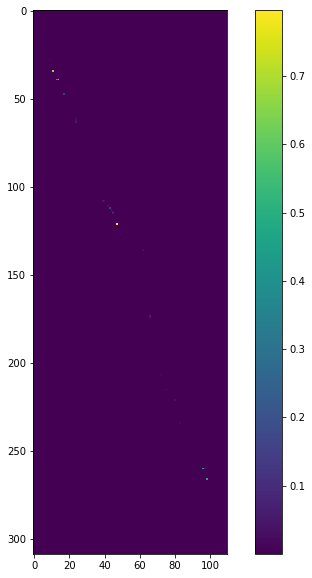

```
Signifikante Funde:
[[[155196, 4, -7], [155191, 4, -7], 0.7964519140989726], [[44933, 4, 18], [44994, 4, -20], 0.6735645240661307], [[49075, 4, 16], [49106, 4, 13], 0.5742883366853191], [[391241, 4, -20], [391190, 4, -11], 0.46824103082518226], [[385789, 4, -8], [385779, 4, 13], 0.45129017657194803], [[49075, 4, 16], […
Signifikanteste Überschneidung:
```

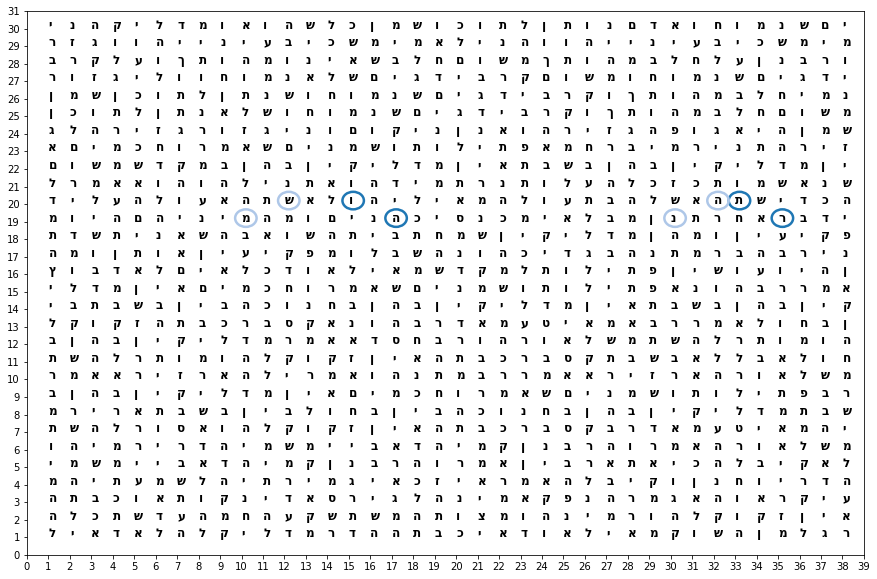

```
Anzeige von Buchstabe 44548 bis 45726
[44933, 'תורה']
```

```python
import biblecode_funktionen
import matplotlib.pyplot
import numpy

buchstabenliste, position_liste = biblecode_funktionen.text_laden("T") #G, E, R, B, T

suchwort1 = "תורה"
suchwort2 = "מנשה"

els1 = biblecode_funktionen.suche_els(buchstabenliste, suchwort1, list(range(-2, -20-1, -1))+list(range(2, 20+1)))
print(els1)
print(str(len(els1)) + " Funde für " + suchwort1)
els2 = biblecode_funktionen.suche_els(buchstabenliste, suchwort2, list(range(-2, -20-1, -1))+list(range(2, 20+1)))
print(els2)
print(str(len(els2)) + " Funde für " + suchwort2)

print("Nähe der einzelnen ELS's:")
nähe = biblecode_funktionen.berechne_nähe(els1,els2)

matplotlib.pyplot.figure(figsize=(10,10))
matplotlib.pyplot.imshow(nähe)
matplotlib.pyplot.colorbar()
matplotlib.pyplot.show()

signifikante_funde = biblecode_funktionen.kompakteste_funde(els1, els2, nähe, 10)
print("Signifikante Funde:")
print(signifikante_funde)

auswahl = 1 #0...9
print("Signifikanteste Überschneidung:")
biblecode_funktionen.display_matrix(buchstabenliste, position_liste, signifikante_funde[auswahl][0], [signifikante_funde[auswahl][1]], 0, 10, 5)
```

```python
from translate import Translator

def translate_hebrew_to_german(text):
    translator = Translator(from_lang='he', to_lang='de')
    translation = translator.translate(text)
    return translation

#if __name__ == "__main__":
#    hebrew_text = input("Gib den hebräischen Text ein, den du ins Deutsche übersetzen möchtest: ")
#    german_text = translate_hebrew_to_german(hebrew_text)
#    print("Übersetzung ins Deutsche:")
#    print(german_text)
```

```python
translate_hebrew_to_german("".join(buchstabenliste[900:1000]))
```

```
'RHarLayukhakarillaExtractionMotherMayEvery object displacementFrom places of pleasureAccompenseKrillaHummerRabineNamikadikAdikNeiPortsFerienCan'
```

```
Hammer - מקביל (Makbil)
Amboss - פלדה (Pil'dah) [Hinweis: "Amboss" wird nicht oft in hebräischen Kontexten erwähnt, aber dies ist das hebräische Wort dafür.]

Himmel - שמים (Shamayim)
Sterne - כוכבים (Kochavim)

Mond - ירח (Yare'ach)
Sonne - שמש (Shemesh)

Erde - אדמה (Adamah)
Wasser - מים (Mayim)

Baum - עץ (Etz)
Blatt - עלה (Ale)

Berg - הר (Har)
Tal - עמק (Emek)

Feuer - אש (Esh)
Rauch - עשן (Eshan)

Licht - אור (Or)
Dunkelheit - חושך (Choshech)

Fluss - נהר (Nahar)
Meer - ים (Yam)

Mensch - אדם (Adam)
Frau - אשה (Isha)

Junge - ילד (Yeled)
Mädchen - ילדה (Yalda)
```

```python
wortpaare = [["פלדה","מקביל"],
            ["כוכבים","שמים"],
            ["ירח","שמש"],
            ["אדמה","מים"],
            ["עמק","עץ"],
            ["עשן","אש"],
            ["חושך","אור"],
            ["ים","נהר"],
            ["אשה","אדם"],
            ["ילדה","ילד"]]
```

```
Paar 0 A: 0 Funde für (Sterne) כוכבים
Paar 0 B: 5 Funde für (Himmel) שמים
Zu wenig Funde. Keine weiteren Berechnungen möglich.
Paar 1 A: 207 Funde für (Mond) ירח
Paar 1 B: 130 Funde für (Sonne) שמש
Signifikante Funde:
[[[49212, 3, -3], [49213, 3, 4], 1.2384615384615387], [[7546, 3, -8], [7545, 3, 8], 1.1935514515883872], [[7546, 3, -8], [7561, 3, -8], 1.1637895468264825], [[49212, 3, -3], [49221, 3, -4], 1.1313186813186813], [[14116, 3, 2], [14133, 3, -5], 0.9100877192982453], [[14116, 3, 2], [14123, 3, 5], 0.765…
```

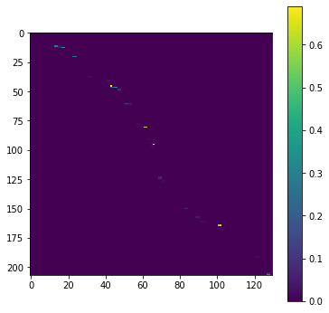

```
Paar 2 A: 7 Funde für (Erde) אדמה
Paar 2 B: 271 Funde für (Wasser) מים
Signifikante Funde:
[[[63801, 4, -5], [63850, 3, -7], 0.0807308287522274], [[63801, 4, -5], [63869, 3, 10], 0.03424470219836991], [[63801, 4, -5], [63734, 3, 4], 0.03249003433484948], [[63801, 4, -5], [63850, 3, 4], 0.026513409393158646], [[47159, 4, -8], [47264, 3, 10], 0.019886681186625097], [[47159, 4, -8], [47233, …
```

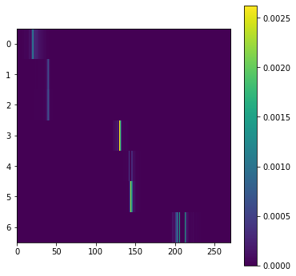

```
Paar 3 A: 2 Funde für (Dunkelheit) חושך
Paar 3 B: 938 Funde für (Licht) אור
Signifikante Funde:
[[[17236, 4, 3], [17315, 3, 6], 0.015945137029428576], [[37821, 4, -2], [37732, 3, 5], 0.009244298720990897], [[37821, 4, -2], [37734, 3, 4], 0.0073615088255136645], [[37821, 4, -2], [37677, 3, -8], 0.00593681704942686], [[37821, 4, -2], [37621, 3, 10], 0.00533914932915886], [[17236, 4, 3], [17424, …
```

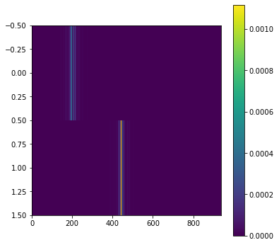

```
Paar 4 A: 490 Funde für (Frau) אשה
Paar 4 B: 136 Funde für (Mann) אדם
Signifikante Funde:
[[[31227, 3, -2], [31224, 3, -4], 1.2142857142857144], [[48354, 3, -4], [48354, 3, 8], 0.8430555555555556], [[60017, 3, 2], [60017, 3, -7], 0.7957880693729751], [[33510, 3, 8], [33502, 3, -7], 0.7863262645344967], [[2899, 3, 4], [2899, 3, -9], 0.776634927635534], [[65497, 3, -4], [65497, 3, -9], 0.7…
```

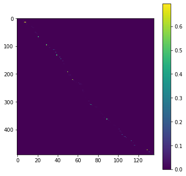

```
Paar 5 A: 22 Funde für (Mädchen) ילדה
Paar 5 B: 249 Funde für (Junge) ילד
Signifikante Funde:
[[[638, 4, -2], [638, 3, -2], 3.0], [[852, 4, -2], [852, 3, -2], 3.0], [[19169, 4, 2], [19169, 3, 2], 3.0], [[25700, 4, -2], [25700, 3, -2], 3.0], [[35162, 4, 3], [35162, 3, 3], 2.277777777777777], [[39458, 4, 3], [39458, 3, 3], 2.277777777777777], [[23252, 4, 4], [23252, 3, 4], 1.6875], [[53217, 4,…
```

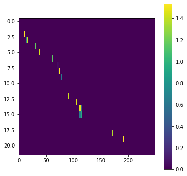

```
Paar 6 A: 10 Funde für (Pflanze) צמח
Paar 6 B: 126 Funde für (Frucht) פרי
Signifikante Funde:
[[[21852, 3, 6], [21830, 3, 5], 0.4074247703515997], [[57548, 3, -6], [57565, 3, 6], 0.287004713220379], [[21852, 3, 6], [21834, 3, -3], 0.16287976037655108], [[57548, 3, -6], [57623, 3, -10], 0.052150666853566056], [[20670, 3, -6], [20598, 3, -5], 0.026177592973134135], [[9283, 3, -5], [9413, 3, -1…
```

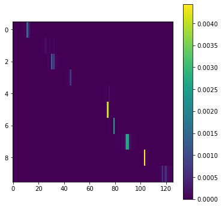

```
Paar 7 A: 87 Funde für (Blitz) ברק
Paar 7 B: 4 Funde für (Karotte) גזר
Signifikante Funde:
[[[25957, 3, 3], [25918, 3, -4], 0.029875801108886036], [[14959, 3, -5], [14775, 3, -6], 0.003231240581226525], [[14442, 3, 5], [14775, 3, -6], 0.0010015281192540732], [[15414, 3, 10], [14775, 3, -6], 0.0005046713732622456], [[14239, 3, 6], [14775, 3, -6], 0.0004441178810157765], [[26367, 3, 4], [25…
```

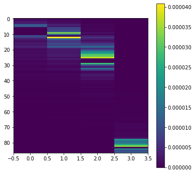

```
Paar 8 A: 2 Funde für (Versöhnung) כפרה
Paar 8 B: 0 Funde für (Hoffnung) תקווה
Zu wenig Funde. Keine weiteren Berechnungen möglich.
Paar 9 A: 381 Funde für (Stadt) עיר
Paar 9 B: 26 Funde für (Dorf) כפר
Signifikante Funde:
[[[73250, 3, 3], [73252, 3, -4], 1.3241758241758246], [[75456, 3, 7], [75461, 3, -3], 0.8270162041348479], [[29152, 3, 8], [29176, 3, -9], 0.7820814181040371], [[28045, 3, 8], [28024, 3, 10], 0.7102564102564103], [[23771, 3, -7], [23760, 3, -7], 0.6543083838079315], [[76528, 3, 8], [76551, 3, 9], 0.…
```

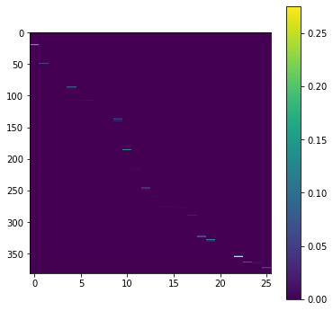

```
Paar 10 A: 1 Funde für (Apfel) תפוח
Paar 10 B: 7 Funde für (Banane) בננה
Zu wenig Funde. Keine weiteren Berechnungen möglich.
Paar 11 A: 1 Funde für (Turm) מגדל
Paar 11 B: 172 Funde für (Wand) קיר
Signifikante Funde:
[[[26583, 4, 6], [26803, 3, 5], 0.0023649628160775996], [[26583, 4, 6], [26269, 3, 10], 0.0023240383595074317], [[26583, 4, 6], [26357, 3, -4], 0.0016481231136115963], [[26583, 4, 6], [26223, 3, 6], 0.0009572852710107616], [[26583, 4, 6], [25963, 3, 10], 0.0005735586841119473], [[26583, 4, 6], [2589…
```

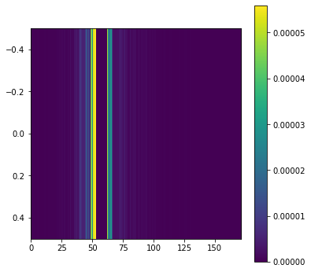

```
Paar 12 A: 127 Funde für (Feld) שדה
Paar 12 B: 0 Funde für (Samen) מזרע
Zu wenig Funde. Keine weiteren Berechnungen möglich.
Paar 13 A: 0 Funde für (Hügel) גבעה
Paar 13 B: 0 Funde für (Gipfel) פסגה
Zu wenig Funde. Keine weiteren Berechnungen möglich.
Paar 14 A: 25 Funde für (Blume) פרח
Paar 14 B: 272 Funde für (Blatt) עלה
Signifikante Funde:
[[[23240, 3, -8], [23237, 3, -2], 0.7501035196687366], [[71779, 3, 7], [71769, 3, 9], 0.6660470572684313], [[60951, 3, 10], [60942, 3, 6], 0.5709353058717851], [[60951, 3, 10], [60979, 3, 4], 0.38181818181818156], [[23240, 3, -8], [23258, 3, 5], 0.23575064235257565], [[18269, 3, -8], [18209, 3, 9], …
```

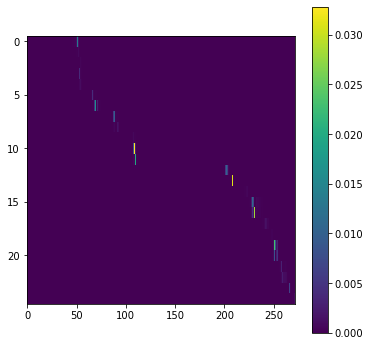

```
Paar 15 A: 0 Funde für (Tisch) שולחן
Paar 15 B: 24 Funde für (Stuhl) כסא
Zu wenig Funde. Keine weiteren Berechnungen möglich.
Paar 16 A: 0 Funde für (Küche) מטבח
Paar 16 B: 41 Funde für (Raum) חדר
Zu wenig Funde. Keine weiteren Berechnungen möglich.
Paar 17 A: 135 Funde für (Tasche) תיק
Paar 17 B: 0 Funde für (Hose) מכנסיים
Zu wenig Funde. Keine weiteren Berechnungen möglich.
```

```python
import biblecode_funktionen
import matplotlib.pyplot
import numpy

buchstabenliste, position_liste = biblecode_funktionen.text_laden("G") #G, E, R, B, T

wortpaare = [
    ["כוכבים", "שמים"],
    ["ירח", "שמש"],
    ["אדמה", "מים"],
    ["חושך", "אור"],
    ["אשה", "אדם"],
    ["ילדה", "ילד"],
    ["צמח", "פרי"],
    ["ברק", "גזר"],
    ["כפרה", "תקווה"],
    ["עיר", "כפר"],
    ["תפוח", "בננה"],
    ["מגדל", "קיר"],
    ["שדה", "מזרע"],
    ["גבעה", "פסגה"],
    ["פרח", "עלה"],
    ["שולחן", "כסא"],
    ["מטבח", "חדר"],
    ["תיק", "מכנסיים"]
]
wortpaare_de = [
    ["Sterne", "Himmel"],
    ["Mond", "Sonne"],
    ["Erde", "Wasser"],
    ["Dunkelheit", "Licht"],
    ["Frau", "Mann"],
    ["Mädchen", "Junge"],
    ["Pflanze", "Frucht"],
    ["Blitz", "Karotte"],
    ["Versöhnung", "Hoffnung"],
    ["Stadt", "Dorf"],
    ["Apfel", "Banane"],
    ["Turm", "Wand"],
    ["Feld", "Samen"],
    ["Hügel", "Gipfel"],
    ["Blume", "Blatt"],
    ["Tisch", "Stuhl"],
    ["Küche", "Raum"],
    ["Tasche", "Hose"]
]

for paar in range(len(wortpaare)):
    suchwort1 = wortpaare[paar][0]
    suchwort2 = wortpaare[paar][1]
    els1 = biblecode_funktionen.suche_els(buchstabenliste, suchwort1, list(range(-2, -10-1, -1))+list(range(2, 10+1)))
    print("Paar "+str(paar)+" A: "+str(len(els1)) + " Funde für (" + wortpaare_de[paar][0] + ") "+ suchwort1)
    els2 = biblecode_funktionen.suche_els(buchstabenliste, suchwort2, list(range(-2, -10-1, -1))+list(range(2, 10+1)))
    print("Paar "+str(paar)+" B: "+str(len(els2)) + " Funde für (" + wortpaare_de[paar][1] + ") "+ suchwort2)

    #print("Nähe der einzelnen ELS's:")
    if len(els1)*len(els2) >= 10:
        print("Signifikante Funde:")
        nähe = biblecode_funktionen.berechne_nähe(els1,els2)
        signifikante_funde = biblecode_funktionen.kompakteste_funde(els1, els2, nähe, 10)
        print(signifikante_funde)
        matplotlib.pyplot.figure(figsize=(6, 6))
        current_aspect = nähe.shape[1] / nähe.shape[0]
        matplotlib.pyplot.imshow(nähe,aspect=current_aspect)
        matplotlib.pyplot.colorbar()
        matplotlib.pyplot.show()
    else:
        print("Zu wenig Funde. Keine weiteren Berechnungen möglich.")


#auswahl = 1 #0...9
#print("Signifikanteste Überschneidung:")
#biblecode_funktionen.display_matrix(buchstabenliste, position_liste, signifikante_funde[auswahl][0], [signifikante_funde[auswahl][1]], 0, 10, 5)
```